# Лабораторна робота №2. Задача класифікації

```python
#імпортуємо бібліотеки NumPy, pandas, scikit-learn та Matplotlib
import pandas as pd
import numpy as np
import matplotlib.pyplot as plt
%matplotlib inline

from sklearn.neighbors import KNeighborsClassifier
from sklearn.linear_model import LogisticRegression
from sklearn.metrics import confusion_matrix, accuracy_score

from sklearn import *
from sklearn.model_selection import train_test_split
from sklearn.model_selection import GridSearchCV, KFold
from sklearn.model_selection import cross_validate
from sklearn.model_selection import learning_curve, validation_curve
```

**1. Підготовка заданого набору даних. Набір даних з минулої роботи (без пропусків і викидів, з бінаризованими якісними та масштабованими кількісними показниками) експортуємо та зберігаємо під назвою adultC.csv.**

```python
df_adult = pd.read_csv('adultC.csv') #імпорт набору даних
df_adult.index = df_adult.index + 1 #індекси починаються з 1
df_adult.drop(df_adult.columns[[0, 105]], axis=1, inplace=True) #видалення стовпця з індексами
df_adult.rename(columns={' >50K': 'Expected_income'}, inplace=True) #перейменування цільової ознаки
df_adult.head(10) #виведення перших 10 рядків
```

|  | Age | Fnlwgt | Capital_gain | Capital_loss | Hours_per_week | Federal-gov | Local-gov | Never-worked | Private | Self-emp-inc | ... | Puerto-Rico | Scotland | South | Taiwan | Thailand | Trinadad&Tobago | United-States | Vietnam | Yugoslavia | Expected_income |
| --- | --- | --- | --- | --- | --- | --- | --- | --- | --- | --- | --- | --- | --- | --- | --- | --- | --- | --- | --- | --- | --- |
| 1 | 0.301370 | 0.044302 | 0.021740 | 0.0 | 0.531250 | 0 | 0 | 0 | 0 | 0 | ... | 0 | 0 | 0 | 0 | 0 | 0 | 1 | 0 | 0 | 0 |
| 2 | 0.452055 | 0.048238 | 0.000000 | 0.0 | 0.109375 | 0 | 0 | 0 | 0 | 0 | ... | 0 | 0 | 0 | 0 | 0 | 0 | 1 | 0 | 0 | 0 |
| 3 | 0.287671 | 0.138113 | 0.000000 | 0.0 | 0.531250 | 0 | 0 | 0 | 1 | 0 | ... | 0 | 0 | 0 | 0 | 0 | 0 | 1 | 0 | 0 | 0 |
| 4 | 0.493151 | 0.151068 | 0.000000 | 0.0 | 0.531250 | 0 | 0 | 0 | 1 | 0 | ... | 0 | 0 | 0 | 0 | 0 | 0 | 1 | 0 | 0 | 0 |
| 5 | 0.150685 | 0.221488 | 0.000000 | 0.0 | 0.531250 | 0 | 0 | 0 | 1 | 0 | ... | 0 | 0 | 0 | 0 | 0 | 0 | 0 | 0 | 0 | 0 |
| 6 | 0.273973 | 0.184932 | 0.000000 | 0.0 | 0.531250 | 0 | 0 | 0 | 1 | 0 | ... | 0 | 0 | 0 | 0 | 0 | 0 | 1 | 0 | 0 | 0 |
| 7 | 0.438356 | 0.100448 | 0.000000 | 0.0 | 0.156250 | 0 | 0 | 0 | 1 | 0 | ... | 0 | 0 | 0 | 0 | 0 | 0 | 0 | 0 | 0 | 0 |
| 8 | 0.479452 | 0.134036 | 0.000000 | 0.0 | 0.609375 | 0 | 0 | 0 | 0 | 0 | ... | 0 | 0 | 0 | 0 | 0 | 0 | 1 | 0 | 0 | 1 |
| 9 | 0.191781 | 0.022749 | 0.140841 | 0.0 | 0.687500 | 0 | 0 | 0 | 1 | 0 | ... | 0 | 0 | 0 | 0 | 0 | 0 | 1 | 0 | 0 | 1 |
| 10 | 0.342466 | 0.099947 | 0.051781 | 0.0 | 0.531250 | 0 | 0 | 0 | 1 | 0 | ... | 0 | 0 | 0 | 0 | 0 | 0 | 1 | 0 | 0 | 1 |

10 rows × 105 columns

**2. Вибір метрики, що буде використовуватись для оцінювання якості класифікації.**

Для оцінювання якості класифікації оберемо метрику accuracy, а цільову ознаку - Expected_income.

```python
#клас не є збалансованим, він має приблизно 75% об'єктів класу 0 та 25% класу 1
df_adult['Expected_income'].value_counts()
```

```
0    24698
1     7839
Name: Expected_income, dtype: int64
```

```python
df_adultB = df_adult[df_adult.iloc[:, 104] == 1]
df_adultB
```

|  | Age | Fnlwgt | Capital_gain | Capital_loss | Hours_per_week | Federal-gov | Local-gov | Never-worked | Private | Self-emp-inc | ... | Puerto-Rico | Scotland | South | Taiwan | Thailand | Trinadad&Tobago | United-States | Vietnam | Yugoslavia | Expected_income |
| --- | --- | --- | --- | --- | --- | --- | --- | --- | --- | --- | --- | --- | --- | --- | --- | --- | --- | --- | --- | --- | --- |
| 8 | 0.479452 | 0.134036 | 0.000000 | 0.0 | 0.609375 | 0 | 0 | 0 | 0 | 0 | ... | 0 | 0 | 0 | 0 | 0 | 0 | 1 | 0 | 0 | 1 |
| 9 | 0.191781 | 0.022749 | 0.140841 | 0.0 | 0.687500 | 0 | 0 | 0 | 1 | 0 | ... | 0 | 0 | 0 | 0 | 0 | 0 | 1 | 0 | 0 | 1 |
| 10 | 0.342466 | 0.099947 | 0.051781 | 0.0 | 0.531250 | 0 | 0 | 0 | 1 | 0 | ... | 0 | 0 | 0 | 0 | 0 | 0 | 1 | 0 | 0 | 1 |
| 11 | 0.273973 | 0.182135 | 0.000000 | 0.0 | 0.531329 | 0 | 0 | 0 | 1 | 0 | ... | 0 | 0 | 0 | 0 | 0 | 0 | 1 | 0 | 0 | 1 |
| 12 | 0.178082 | 0.087619 | 0.000000 | 0.0 | 0.531250 | 0 | 0 | 0 | 0 | 0 | ... | 0 | 0 | 0 | 0 | 0 | 0 | 0 | 0 | 0 | 1 |
| ... | ... | ... | ... | ... | ... | ... | ... | ... | ... | ... | ... | ... | ... | ... | ... | ... | ... | ... | ... | ... | ... |
| 32516 | 0.739726 | 0.186826 | 0.000000 | 0.0 | 0.062500 | 0 | 0 | 0 | 1 | 0 | ... | 0 | 0 | 0 | 0 | 0 | 0 | 1 | 0 | 0 | 1 |
| 32522 | 0.301370 | 0.067382 | 0.000000 | 0.0 | 0.218750 | 0 | 1 | 0 | 0 | 0 | ... | 0 | 0 | 0 | 0 | 0 | 0 | 1 | 0 | 0 | 1 |
| 32531 | 0.493151 | 0.210253 | 0.000000 | 0.0 | 0.531250 | 0 | 0 | 0 | 1 | 0 | ... | 0 | 0 | 0 | 0 | 0 | 0 | 1 | 0 | 0 | 1 |
| 32534 | 0.315068 | 0.096500 | 0.000000 | 0.0 | 0.531250 | 0 | 0 | 0 | 1 | 0 | ... | 0 | 0 | 0 | 0 | 0 | 0 | 1 | 0 | 0 | 1 |
| 32537 | 0.479452 | 0.187203 | 0.150242 | 0.0 | 0.531250 | 0 | 0 | 0 | 0 | 1 | ... | 0 | 0 | 0 | 0 | 0 | 0 | 1 | 0 | 0 | 1 |

7839 rows × 105 columns

```python
df_balanced = pd.concat([df_adult, df_adultB, df_adultB, df_adultB])
df_balanced['Expected_income'].value_counts()
```

```
1    31356
0    24698
Name: Expected_income, dtype: int64
```

```python
#створення набору даних, що містить рівну кількість класових ознак
#df_adultA = df_adult[df_adult.iloc[:, 104] == 0]
#df_adultA = df_adultA.iloc[:7839]
#df_AB = pd.concat([df_adultA, df_adultB])
#df_AB['Expected_income'].value_counts()
```

**3. Розбиваємо набір даних на навчальну та тестову частини функцією train_test_split.**

```python
#розбиваємо датафрейм на тестову та навчальну частини
#X = df_AB.iloc[:, :103]
#y = df_AB.iloc[:, 104]
X = df_balanced.iloc[:, :103]
y = df_balanced.iloc[:, 104]
X_train, X_test, y_train, y_test = train_test_split(X, y, test_size=0.3, shuffle=True)
X_test.head() #перші 5 рядків тестової частини
```

|  | Age | Fnlwgt | Capital_gain | Capital_loss | Hours_per_week | Federal-gov | Local-gov | Never-worked | Private | Self-emp-inc | ... | Poland | Portugal | Puerto-Rico | Scotland | South | Taiwan | Thailand | Trinadad&Tobago | United-States | Vietnam |
| --- | --- | --- | --- | --- | --- | --- | --- | --- | --- | --- | --- | --- | --- | --- | --- | --- | --- | --- | --- | --- | --- |
| 388 | 0.369863 | 0.101699 | 0.000000 | 0.554408 | 0.000000 | 0 | 0 | 0 | 1 | 0 | ... | 0 | 0 | 0 | 0 | 0 | 0 | 0 | 0 | 1 | 0 |
| 11869 | 0.232877 | 0.135681 | 0.074431 | 0.000000 | 0.453125 | 0 | 0 | 0 | 1 | 0 | ... | 0 | 0 | 0 | 0 | 0 | 0 | 0 | 0 | 1 | 0 |
| 21648 | 0.301370 | 0.118104 | 0.000000 | 0.000000 | 0.531250 | 0 | 0 | 0 | 1 | 0 | ... | 0 | 0 | 0 | 0 | 0 | 0 | 0 | 0 | 1 | 0 |
| 6266 | 0.013699 | 0.033072 | 0.000000 | 0.000000 | 0.531329 | 0 | 0 | 0 | 0 | 0 | ... | 0 | 0 | 0 | 0 | 0 | 0 | 0 | 0 | 1 | 0 |
| 30895 | 0.123288 | 0.083916 | 0.000000 | 0.000000 | 0.484375 | 0 | 0 | 0 | 1 | 0 | ... | 0 | 0 | 0 | 0 | 0 | 0 | 0 | 0 | 1 | 0 |

5 rows × 103 columns

**4. Навчаємо два класифікатори та оцінюємо їх якість.**

Використовуємо класифікатори k найближчих сусідів (k Nearest Neighbors) та логістичну регресію (Logistic Regression) з бібліотеки scikit-learn.

```python
#виконуємо навчання логістичної регресії з параметрами за замовчуванням
#X_train, y_train
clf = LogisticRegression(max_iter = 10000, penalty='none')
clf.fit(X_train, y_train)
```

```
LogisticRegression(max_iter=10000, penalty='none')
```

```python
#повертаємо прогнозовані класи для об'єктів вибірки, розраховуємо метрики якості та матриці помилок
#відкладена вибірка
y_pred = clf.predict(X_train)
print('train')
print(accuracy_score(y_train, y_pred))
print(confusion_matrix(y_train, y_pred))

y_pred = clf.predict(X_test)
print('test')
print(accuracy_score(y_test, y_pred))
print(confusion_matrix(y_test, y_pred))
```

```
train
0.832071768993552
[[13085  4076]
 [ 2513 19563]]
test
0.8296961408098947
[[5720 1817]
 [1047 8233]]
```

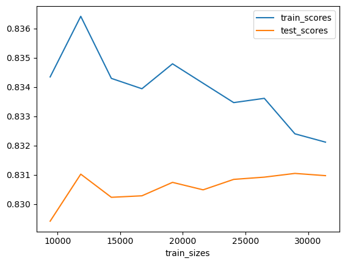

```python
#використовуємо клас KFold з розбиттям на 5 блоків та перемішуванням
clf = LogisticRegression(max_iter = 10000, penalty='none') #збільшення кількості ітерацій
train_sizes, train_scores, test_scores = learning_curve(clf, X_train, y_train,
                                                        train_sizes=np.linspace(0.3, 1, 10), cv=KFold(5, shuffle=True))
#будуємо графік та усередненими значеннями навчальної та тестової вибірки
plt.plot(train_sizes, train_scores.mean(axis=1), label='train_scores')
plt.plot(train_sizes, test_scores.mean(axis=1), label='test_scores')
plt.xlabel('train_sizes')
#plt.ylim((0.7, 0.9))
plt.legend()
```

Зі збільшенням обсягу навчальної вибірки збільшується точність прогнозування.

```python
#виконуємо навчання логістичної регресії з підбором значень гіперпараметрів
clf = LogisticRegression(penalty='l2', solver='liblinear') #використання регуляризації l2
param_range = [0.1, 0.5, 1, 2, 3, 4, 5, 10]
for C in param_range:
    clf.set_params(C=C)
    clf.fit(X_train, y_train)
#повертаємо прогнозовані класи для об'єктів вибірки, розраховуємо метрики якості та матриці помилок
    y_pred=clf.predict(X_train)
    print('train, C =', C)
    print(accuracy_score(y_train, y_pred))
    print(confusion_matrix(y_train, y_pred))
    y_pred = clf.predict(X_test)
    print('test, C =', C)
    print(accuracy_score(y_test, y_pred))
    print(confusion_matrix(y_test, y_pred))
    print()
```

```
train, C = 0.1
0.8247317582893697
[[12715  4446]
 [ 2431 19645]]
test, C = 0.1
0.8213117678539573
[[5553 1984]
 [1021 8259]]

train, C = 0.5
0.8290389173484212
[[12925  4236]
 [ 2472 19604]]
test, C = 0.5
0.8253552952369626
[[5648 1889]
 [1048 8232]]

train, C = 1
0.8312816983969212
[[12971  4190]
 [ 2430 19646]]
test, C = 1
0.8271392043765238
[[5660 1877]
 [1030 8250]]

train, C = 2
0.8324285750694498
[[13017  4144]
 [ 2431 19645]]
test, C = 2
0.8290420407920557
[[5679 1858]
 [1017 8263]]

train, C = 3
0.8327344088487907
[[13035  4126]
 [ 2437 19639]]
```

[output cut: 16 more lines]

```
[[13048  4113]
 [ 2469 19607]]
test, C = 5
0.8297556044478801
[[5697 1840]
 [1023 8257]]

train, C = 10
0.8321227412901089
[[13067  4094]
 [ 2493 19583]]
test, C = 10
0.8296366771719094
[[5703 1834]
 [1031 8249]]
```

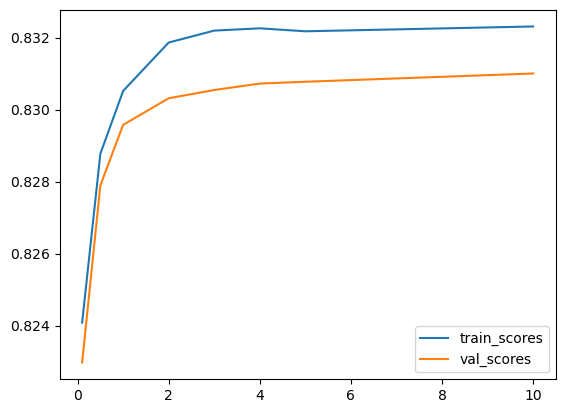

```python
#побудова валідаційної кривої для вибору найкращого значення параметра регуляризації для логістичної регресії
clf = LogisticRegression(penalty='l2', solver='liblinear')
param_range = [0.1, 0.5, 1, 2, 3, 4, 5, 10]
train_scores, val_scores = validation_curve(clf, X_train, y_train, param_name='C', param_range=param_range,
                                            scoring='accuracy', cv=KFold(5, shuffle=True))
plt.plot(param_range, train_scores.mean(axis=1), label='train_scores')
plt.plot(param_range, val_scores.mean(axis=1), label='val_scores')
#plt.ylim((0.7, 0.9))
plt.legend()
```

Зі збільшенням параметра C збільшується точність прогнозування. Параметр С = 5 є оптимальним, при ньому крива вирівнюється та продовжує повільний зріст.

```python
#перевизначення функції з параметром С = 5
clf = LogisticRegression(penalty='l2', solver='liblinear', C=5)
#крос-валідація
cv_res = cross_validate(clf, X_train, y_train,
                       scoring='accuracy', cv=KFold(5, shuffle=False),
                        return_train_score=True)
print('train')
print(cv_res['train_score'])
print('test')
print(cv_res['test_score'])
```

```
train
[0.83226608 0.83095989 0.83208028 0.83169799 0.83395986]
test
[0.8312946  0.83167686 0.83496878 0.8312731  0.82617561]
```

```python
#пропускаємо повідомлення про майбутні помилки
import warnings
warnings.simplefilter(action='ignore', category=FutureWarning)

#розбиваємо навчальну вибірку
X_train2, X_val, y_train2, y_val = train_test_split(X_train, y_train, test_size=0.3, shuffle=True)

#виконуємо навчання k найближчих сусідів з підбором значень гіперпараметрів
param_range = [1, 2, 3, 4, 5, 6, 7, 8, 9, 10]
for k in param_range:
    knn = KNeighborsClassifier(n_neighbors=k)
    knn.fit(X_train2, y_train2)

    y_pred = knn.predict(X_train2)
    print('train, k =', k)
    print(accuracy_score(y_train2, y_pred))
    print(confusion_matrix(y_train2, y_pred))
    y_pred = knn.predict(X_val)
    print('test, k =', k)
    print(accuracy_score(y_val, y_pred))
    print(confusion_matrix(y_val, y_pred))
    print()
```

```
train, k = 1
1.0
[[11976     0]
 [    0 15489]]
test, k = 1
0.88642541624193
[[4147 1038]
 [ 299 6288]]

train, k = 2
0.9768432550518842
[[11976     0]
 [  636 14853]]
test, k = 2
0.8268773360516479
[[4292  893]
 [1145 5442]]

train, k = 3
0.9156380848352449
[[ 9984  1992]
 [  325 15164]]
test, k = 3
0.8273870200475705
[[3799 1386]
 [ 646 5941]]

train, k = 4
0.8971782268341526
[[10477  1499]
 [ 1325 14164]]
test, k = 4
0.8073394495412844
[[4089 1096]
 [1172 5415]]

train, k = 5
0.8765337702530493
[[ 9454  2522]
 [  869 14620]]
```

[output cut: 34 more lines]

```
[[ 9166  2810]
 [ 1298 14191]]
test, k = 9
0.8177030241250425
[[3799 1386]
 [ 760 5827]]

train, k = 10
0.8470780993992354
[[ 9505  2471]
 [ 1729 13760]]
test, k = 10
0.8154094461433911
[[3944 1241]
 [ 932 5655]]
```

Найбільш оптимальним є параметр k = 1 при точності 88,6%.

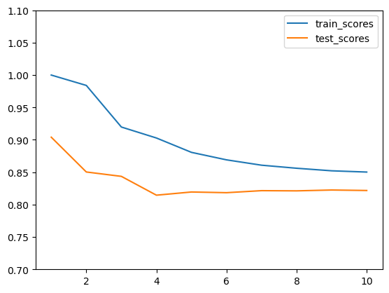

```python
#побудова валідаційної кривої для вибору найкращого значення параметра k для класифікатора k найближчих сусідів
knn = KNeighborsClassifier(n_neighbors=k)
param_range = [1, 2, 3, 4, 5, 6, 7, 8, 9, 10]
train_scores, test_scores = validation_curve(knn, X_train, y_train, param_name='n_neighbors', param_range=param_range,
                                            scoring='accuracy', cv=KFold(5, shuffle=True))
plt.plot(param_range, train_scores.mean(axis=1), label='train_scores')
plt.plot(param_range, test_scores.mean(axis=1), label='test_scores')
plt.ylim((0.7, 1.1))
plt.legend()
```

Зі збільшенням ітерації параметра k зменшується точність прогнозування, але після k = 4 точність знову підвищується.

```python
#перевизначення функції з параметром k = 1
knn = KNeighborsClassifier(n_neighbors = 1)

#крос-валідація
cv_res = cross_validate(knn, X_train, y_train,
                       scoring='accuracy', cv=KFold(5, shuffle=False),
                        return_train_score=True)
print('train')
print(cv_res['train_score'])
print('test')
print(cv_res['test_score'])
```

```
train
[1. 1. 1. 1. 1.]
test
[0.90545362 0.9004842  0.90200076 0.907608   0.90123614]
```

**5. Використовуємо модуль GridSearchCV з бібліотеки scikit-learn для автоматичного підбору гіперпараметрів.**

```python
#автоматичний підбір гіперпараметрів для логістичної регресії
clf = LogisticRegression(solver='liblinear')
parameters = {'penalty':['l2']}, {'C': [0.1, 0.5, 1, 2, 3, 4, 5, 10]}
grid_search = GridSearchCV(clf, param_grid=parameters, scoring='accuracy',
                          cv=KFold(5, shuffle=True), return_train_score=True)
grid_search.fit(X_train, y_train)
```

```
GridSearchCV(cv=KFold(n_splits=5, random_state=None, shuffle=True),
             estimator=LogisticRegression(solver='liblinear'),
             param_grid=({'penalty': ['l2']},
                         {'C': [0.1, 0.5, 1, 2, 3, 4, 5, 10]}),
             return_train_score=True, scoring='accuracy')
```

```python
#виведення найкращого результату та найкращих параметрів
print('best_params', grid_search.best_params_)
print('best_score', grid_search.best_score_)
```

```
best_params {'C': 10}
best_score 0.8306699502864869
```

```python
#автоматичний підбір гіперпараметрів для k найближчих сусідів
knn = KNeighborsClassifier(n_neighbors=k)
parameters = {'n_neighbors': [1, 2, 3, 4, 5, 6, 7, 8, 9, 10]}
grid_search = GridSearchCV(knn, param_grid=parameters, scoring='accuracy',
                          cv=KFold(5, shuffle=True), return_train_score=True)
grid_search.fit(X_train, y_train)
```

```
GridSearchCV(cv=KFold(n_splits=5, random_state=None, shuffle=True),
             estimator=KNeighborsClassifier(n_neighbors=10),
             param_grid={'n_neighbors': [1, 2, 3, 4, 5, 6, 7, 8, 9, 10]},
             return_train_score=True, scoring='accuracy')
```

```python
#виведення найкращого результату та найкращих параметрів
print('best_params', grid_search.best_params_)
print('best_score', grid_search.best_score_)
```

```
best_params {'n_neighbors': 1}
best_score 0.9047326500566972
```

Відповідно до результату автоматичного підбору параметрів, найбільш якісним є параметр k = 1 для k найближчих сусідів та C = 10 для логістичної регресії.